# Relatório 4

6 de abril de 2017

# Laboratorio 1 - checkpoint 4

## Fundamentos de Pesquisa em Ciência da Computação 2

Os dados utilizados para análise desse relatório foram obtidos do site da Câmara de deputados. O línk para os dados: http://www2.camara.leg.br/transparencia/cota-para-exercicio-da-atividade-parlamentar/dados-abertos-cota-parlamentar

Agora, observemos algumas das variáveis em estudo:

Tipo de despesas:

```r
todos_os_dep %>% select(txtDescricao) %>% distinct()
```

| txtDescricao |
| --- |
| COMBUSTÍVEIS E LUBRIFICANTES. |
| DIVULGAÇÃO DA ATIVIDADE PARLAMENTAR. |
| SERVIÇO DE SEGURANÇA PRESTADO POR EMPRESA ESPECIALIZADA. |
| TELEFONIA |
| SERVIÇOS POSTAIS |
| LOCAÇÃO OU FRETAMENTO DE VEÍCULOS AUTOMOTORES |
| Emissão Bilhete Aéreo |
| MANUTENÇÃO DE ESCRITÓRIO DE APOIO À ATIVIDADE PARLAMENTAR |
| FORNECIMENTO DE ALIMENTAÇÃO DO PARLAMENTAR |
| LOCAÇÃO OU FRETAMENTO DE AERONAVES |

[output cut: 8 more lines]

```r
todos_os_dep$txtDescricao[todos_os_dep$txtDescricao == "Emissão Bilhete Aéreo"] <- "PASSAGENS AÉREAS"
```

Percebemos aqui uma incoerência entre Emissão Bilhete Aéreo e PASSAGENS_AEREAS. Percebemos que possívelmente se trata do mesmo tipo de gasto. Os devidos tratamentos foram feitos. Partidos:

```r
todos_os_dep %>% select(sgPartido) %>% distinct()
```

| sgPartido |
| --- |
| DEM |
| PP |
| PTB |
| PT |
| PR |
| PTN |
| PSDB |
| PSB |
| PDT |
| PRB |

[output cut: 17 more lines]

Parlamentares:

```r
todos_os_dep %>% select(txNomeParlamentar) %>% distinct()
```

| txNomeParlamentar |
| --- |
| ABEL MESQUITA JR. |
| ADAIL CARNEIRO |
| ADALBERTO CAVALCANTI |
| ADELMO CARNEIRO LEÃO |
| ADELSON BARRETO |
| ADEMIR CAMILO |
| ADÉRMIS MARINI |
| ADILTON SACHETTI |
| AELTON FREITAS |
| AFONSO FLORENCE |

[output cut: 528 more lines]

Agora, passemos às perguntas:

## 1.Considerando o gasto médio ( gasto do partido/ número de deputados), quais os partidos que mais gastam?

Vamos analisar os gastos agora por partido

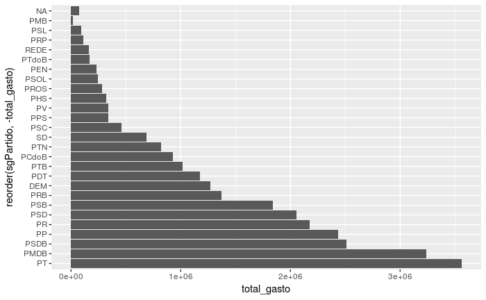

```r
gastos_por_partido = todos_os_dep %>% group_by(sgPartido) %>% summarise(total_gasto = sum(vlrLiquido)) %>% arrange(-total_gasto)
gastos_por_partido %>% ggplot(aes(x=reorder(sgPartido,-total_gasto), y = total_gasto)) + geom_bar(stat="identity") + coord_flip()
```

Observamos que nesse caso os dois partidos que mais gastam são o PT e o PMDB. Todavia, não consideramos, no caso acima, o número de deputados por partido.

Vamos agora considerar o gasto médio do partido, sendo este proporcional ao número de deputados do mesmo:

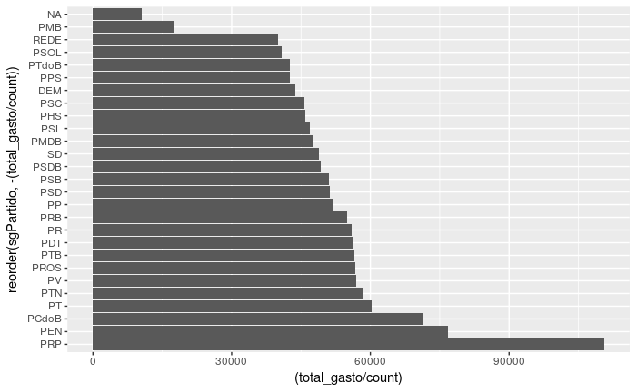

```r
gastos_medio_por_dep_partido = todos_os_dep %>% group_by(sgPartido, txNomeParlamentar) %>% summarise(total_gasto = sum(vlrLiquido)) %>% group_by(sgPartido) %>% summarise(count=n(), total_gasto=sum(total_gasto))
gastos_medio_por_dep_partido %>% ggplot(aes(x=reorder(sgPartido,-(total_gasto/count)),y=(total_gasto/count))) +
  geom_bar(stat="identity") + coord_flip()
```

Olhando o gasto pelo número de deputados, percebemos que , na verdade, o partido com maior gasto é o PRP. O PT deixou o topo.

Vamos agora analisar o gasto por deputado do partido com o segundo maior gasto, dado que, o primeiro com maior gasto possuí apenas um deputado, o sr NIVALDO ALBUQUERQUE.

Para o segundo com maior gasto:

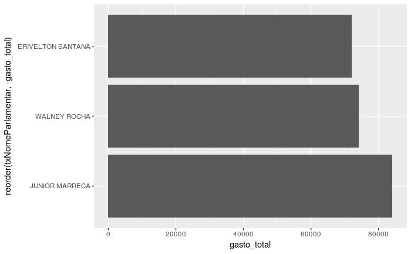

```r
gastos_pp = todos_os_dep %>% filter(sgPartido=="PEN") %>% group_by(txNomeParlamentar) %>% summarise(gasto_total = sum(vlrLiquido))
gastos_pp %>% ggplot(aes(x=reorder(txNomeParlamentar,-gasto_total),y=gasto_total)) + geom_bar(stat="identity") + coord_flip()
```